# Fairness & Bias Analysis

This notebook loads pre-computed group fairness metrics (produced by `fairness_audit.py`) and generates visualizations to inspect disparities across targets and demographic groups.

Artifacts expected in `project/artifacts`:

- `fairness_group_metrics.csv` (generated)
- model + calibration artifacts (already produced by training pipeline)

If the CSV is missing, run in a terminal: `python project/fairness_audit.py --artifacts project/artifacts --out project/artifacts/fairness_group_metrics.csv`. Current notebook can also recompute directly (see next cell).

```python
# Fairness metrics recomputation (self-contained)
# Set FORCE_RECOMPUTE=True to regenerate CSV even if it exists.
FORCE_RECOMPUTE = True
APPLY_TEST_SPLIT = True  # restrict evaluation to test split subjects only
TEST_IDS_FILE_CANDIDATES = [
    'test_subject_ids.txt',          # newly persisted plain-text list from training pipeline
    'data_split_manifest.json',      # new manifest (preferred JSON source)
    'split_subject_ids.json',        # legacy / alternate naming
    'subject_ids_test.txt',          # fallback alt text naming
]
import json, math, os, random
from pathlib import Path
import numpy as np, pandas as pd
from joblib import load as jobload
from sklearn.metrics import roc_auc_score, average_precision_score, brier_score_loss, f1_score, precision_score, recall_score
MIN_GROUP = 30
TARGETS = [('mortality','mortality_label'),('prolonged_los','prolonged_los_label'),('readmission','readmission_label')]
# Robust artifact directory resolution supporting running from nested 'notebooks/'
ARTIFACT_DIR = None
env_dir = os.getenv('FAIRNESS_ARTIFACT_DIR')
if env_dir:
    p = Path(env_dir)
    if (p / 'labels.csv').exists() and (p / 'features_full.parquet').exists():
        ARTIFACT_DIR = p
if ARTIFACT_DIR is None:
    search_roots = [Path.cwd()] + list(Path.cwd().parents)[:4]
    tried = []
    for root in search_roots:
        candidates = [root / 'project' / 'artifacts', root / 'artifacts']
        for c in candidates:
            tried.append(str(c))
            if (c / 'labels.csv').exists() and (c / 'features_full.parquet').exists():
                ARTIFACT_DIR = c
                break
        if ARTIFACT_DIR is not None:
            break
if ARTIFACT_DIR is None:
    raise FileNotFoundError('Could not locate artifacts directory with labels.csv and features_full.parquet. Tried: ' + '\n'.join(tried))
ARTIFACT_DIR = ARTIFACT_DIR.resolve()
print('Using artifacts at:', ARTIFACT_DIR)
OUT_CSV = ARTIFACT_DIR / 'fairness_group_metrics.csv'

TEST_SUBJECT_IDS = None
TEST_SPLIT_SOURCE = None

def _load_test_subject_ids(art_dir: Path, labels_df: pd.DataFrame) -> tuple[set[int] | None, str | None]:
    # 1. Environment override
    env_file = os.getenv('FAIRNESS_TEST_IDS_FILE')
    if env_file and Path(env_file).exists():
        ids = {int(x.strip()) for x in Path(env_file).read_text().splitlines() if x.strip().isdigit()}
        return ids & set(labels_df['subject_id'].astype(int)), f'env:{env_file}'
    # 2. Preferred plain-text then JSON sources in declared order
    for name in TEST_IDS_FILE_CANDIDATES:
        p = art_dir / name
        if p.exists() and p.suffix.lower() == '.txt':
            ids = {int(x.strip()) for x in p.read_text().splitlines() if x.strip().isdigit()}
            return ids & set(labels_df['subject_id'].astype(int)), str(p.name)
    # 3. JSON sources (supports new manifest structure)
    for name in TEST_IDS_FILE_CANDIDATES:
        p = art_dir / name
        if p.exists() and p.suffix.lower() == '.json':
            try:
                data = json.loads(p.read_text())
                # New manifest: data_split_manifest.json has subject_ids.test
                if 'subject_ids' in data and isinstance(data['subject_ids'], dict):
                    if 'test' in data['subject_ids'] and isinstance(data['subject_ids']['test'], list):
                        ids = {int(v) for v in data['subject_ids']['test'] if str(v).isdigit()}
                        return ids & set(labels_df['subject_id'].astype(int)), f'{p.name}:subject_ids.test'
                # Legacy keys fallback
                for k in ['test','test_ids','test_subject_ids']:
                    if k in data and isinstance(data[k], list):
                        ids = {int(v) for v in data[k] if str(v).isdigit()}
                        return ids & set(labels_df['subject_id'].astype(int)), f'{p.name}:{k}'
            except Exception:
                pass
    # 4. Synthetic reconstruction (last resort)
    metrics_any = None
    for tgt,_ in TARGETS:
        mpath = art_dir / f'metrics_{tgt}.json'
        if mpath.exists():
            metrics_any = json.loads(mpath.read_text())
            break
    if metrics_any and {'train_rows','val_rows','test_rows'} <= set(metrics_any.keys()):
        train_n = int(metrics_any['train_rows']); val_n = int(metrics_any['val_rows']); test_n = int(metrics_any['test_rows'])
        all_ids = labels_df['subject_id'].astype(int).tolist()
        rng = random.Random(2025)
        sorted_ids = sorted(all_ids)
        rng.shuffle(sorted_ids)
        test_ids = set(sorted_ids[train_n + val_n: train_n + val_n + test_n])
        return test_ids, f'synthetic_split(seed=2025, counts={train_n}/{val_n}/{test_n})'
    return None, None

def load_artifacts(adir: Path):
    labels_df = pd.read_csv(adir / 'labels.csv')
    feats = pd.read_parquet(adir / 'features_full.parquet')
    if 'subject_id' in feats.columns: feats = feats.set_index('subject_id')
    feats.index = feats.index.astype(int)
    labels_df = labels_df.drop_duplicates('subject_id')
    labels_df['subject_id'] = labels_df['subject_id'].astype(int)
    feats = feats.loc[labels_df['subject_id']]
    schema_path = adir / 'feature_columns.json'
    if schema_path.exists():
        schema_cols = json.loads(schema_path.read_text())
        for m in [c for c in schema_cols if c not in feats.columns]: feats[m] = 0.0
        feats = feats.reindex(columns=schema_cols)
    return labels_df, feats

def get_probs(tgt, X, adir: Path):
    base = adir / f'model_{tgt}.joblib'
    iso = adir / f'isotonic_{tgt}.joblib'
    full = adir / f'model_full_{tgt}.joblib'
    if base.exists() and iso.exists():
        raw = jobload(base).predict_proba(X)[:,1]
        iso_m = jobload(iso)
        if hasattr(iso_m,'transform'): return iso_m.transform(raw), 'base_cal'
        if hasattr(iso_m,'predict'): return iso_m.predict(raw), 'base_cal'
        return raw, 'base_raw'
    if full.exists(): return jobload(full).predict_proba(X)[:,1], 'full_raw'
    raise FileNotFoundError(f'Missing models for {tgt}')

def derive_threshold(y_true, probs):
    best_f1, best_thr = -1.0, 0.5
    for t in np.linspace(0.01,0.99,150):
        f1v = f1_score(y_true, (probs>=t).astype(int), zero_division=0)
        if f1v > best_f1: best_f1, best_thr = f1v, float(t)
    return best_thr

def add_group(rows, *, tgt, mode, gtype, gval, mask, y, p, thr, g_auc, g_f1):
    if mask.sum() < MIN_GROUP: return
    yg, pg = y[mask], p[mask]
    if len(np.unique(yg)) > 1:
        try: auc_g = roc_auc_score(yg, pg)
        except: auc_g = np.nan
    else: auc_g = np.nan
    try: pr_g = average_precision_score(yg, pg) if yg.sum()>0 else np.nan
    except: pr_g = np.nan
    try: brier_g = brier_score_loss(yg, pg)
    except: brier_g = np.nan
    predg = (pg>=thr).astype(int)
    f1g = f1_score(yg, predg, zero_division=0) if yg.sum()>0 else np.nan
    rows.append(dict(target=tgt, prob_source=mode, group_category=gtype, group_value=gval, n=int(mask.sum()), prevalence=float(yg.mean()) if len(yg) else np.nan, auc=auc_g, pr_auc=pr_g, brier=brier_g, threshold=thr, f1=f1g, precision=precision_score(yg,predg,zero_division=0), recall=recall_score(yg,predg,zero_division=0), global_auc=g_auc, global_f1=g_f1, delta_auc= (auc_g - g_auc) if (auc_g is not None and not np.isnan(auc_g)) else np.nan, delta_f1= (f1g - g_f1) if (f1g is not None and not np.isnan(f1g)) else np.nan))

def compute_fairness(adir: Path, out_csv: Path):
    global TEST_SUBJECT_IDS, TEST_SPLIT_SOURCE
    labels_df, feats = load_artifacts(adir)
    if APPLY_TEST_SPLIT:
        TEST_SUBJECT_IDS, TEST_SPLIT_SOURCE = _load_test_subject_ids(adir, labels_df)
        if TEST_SUBJECT_IDS is None:
            raise RuntimeError('Requested test-only evaluation but no explicit test subject IDs file. Provide FAIRNESS_TEST_IDS_FILE env var or artifacts/test_subject_ids.txt')
        mask = labels_df['subject_id'].astype(int).isin(TEST_SUBJECT_IDS)
        labels_df = labels_df[mask].copy()
        feats = feats.loc[labels_df['subject_id']]
        print(f'Applied test split filter: subjects={len(labels_df)} source={TEST_SPLIT_SOURCE}')
    X = feats.values
    rows = []
    label_map = {lc: labels_df[lc].astype(int).to_numpy() for _,lc in TARGETS if lc in labels_df.columns}
    thresholds = {}
    for tgt,_ in TARGETS:
        tp = adir / f'threshold_{tgt}.txt'
        thresholds[tgt] = float(tp.read_text().strip()) if tp.exists() else None
    # Gender columns: include only base one-hot indicators, exclude any measured/missingness variants
    raw_gender_cols = [c for c in feats.columns if c.lower().startswith('gender_')]
    gender_cols = [c for c in raw_gender_cols if '__' not in c.lower() and c.lower() in ('gender_m','gender_f')]
    eth_cols = [c for c in feats.columns if c.lower().startswith('eth_')]
    age_band = None
    if 'age' in feats.columns:
        age_series = feats['age'].clip(0,120)
        # Existing custom fine bins preserved
        age_band = pd.cut(age_series, [0,1,20,30,40,50,60,70,80,200], labels=['0-1','1-20','20-30','30-40','40-50','50-60','60-70','70-80','80+'], right=False)
    for tgt, label_col in TARGETS:
        if label_col not in label_map: continue
        y = label_map[label_col]
        if len(np.unique(y)) < 2: continue
        probs, mode = get_probs(tgt, X, adir)
        g_auc = roc_auc_score(y, probs)
        thr = thresholds.get(tgt)
        if thr is None or math.isnan(thr): thr = derive_threshold(y, probs)
        pred = (probs>=thr).astype(int)
        g_f1 = f1_score(y, pred, zero_division=0)
        for gc in gender_cols:
            add_group(rows, tgt=tgt, mode=mode, gtype='gender', gval=gc.split('_',1)[1].upper(), mask=(feats[gc]==1).values, y=y, p=probs, thr=thr, g_auc=g_auc, g_f1=g_f1)
        for ec in eth_cols:
            add_group(rows, tgt=tgt, mode=mode, gtype='ethnicity', gval=ec.split('_',1)[1].upper(), mask=(feats[ec]==1).values, y=y, p=probs, thr=thr, g_auc=g_auc, g_f1=g_f1)
        if age_band is not None:
            for ab in age_band.dropna().unique():
                mask = (age_band == ab).values
                add_group(rows, tgt=tgt, mode=mode, gtype='age_band', gval=str(ab), mask=mask, y=y, p=probs, thr=thr, g_auc=g_auc, g_f1=g_f1)
    if not rows: raise RuntimeError('No group rows produced.')
    df = pd.DataFrame(rows).sort_values(['target','group_category','group_value'])
    suffix = '_test' if APPLY_TEST_SPLIT else ''
    out_path = out_csv if not APPLY_TEST_SPLIT else (out_csv.parent / f'{out_csv.stem}{suffix}{out_csv.suffix}')
    df.to_csv(out_path, index=False)
    print('Wrote fairness metrics ->', out_path.name)
    return df

if FORCE_RECOMPUTE or not OUT_CSV.exists():
    print('Recomputing fairness metrics...')
    _df = compute_fairness(ARTIFACT_DIR, OUT_CSV)
else:
    print('Using existing metrics at', OUT_CSV)
print('Artifact directory resolved:', ARTIFACT_DIR)
```

[output not shown]

```python
# Global sanity check: compare fresh overall metrics to stored training metrics
import json
from pathlib import Path
from sklearn.metrics import roc_auc_score, average_precision_score, brier_score_loss, f1_score, precision_score, recall_score
SANITY_TOL = 0.01  # allowable absolute difference in key metrics
HARD_FAIL = False  # set True to raise if discrepancy beyond tolerance
RESAMPLE_THRESHOLDS = False  # if True, derive threshold on (test) subset instead of stored threshold
metrics_files = {t: ARTIFACT_DIR / f'metrics_{t}.json' for t,_ in [('mortality','mortality_label'),('prolonged_los','prolonged_los_label'),('readmission','readmission_label')]}

# Reuse already loaded artifacts from earlier cell to ensure same (test) restriction
labels_df, feats = load_artifacts(ARTIFACT_DIR)
if 'APPLY_TEST_SPLIT' in globals() and APPLY_TEST_SPLIT and 'TEST_SUBJECT_IDS' in globals() and TEST_SUBJECT_IDS:
    labels_df = labels_df[labels_df['subject_id'].astype(int).isin(TEST_SUBJECT_IDS)].copy()
    feats = feats.loc[labels_df['subject_id']]
    print(f'Sanity check restricted to test subjects: {len(labels_df)} (source={TEST_SPLIT_SOURCE})')
else:
    if 'APPLY_TEST_SPLIT' in globals() and APPLY_TEST_SPLIT:
        print('WARNING: test split requested but TEST_SUBJECT_IDS missing; using full data for sanity check.')
X = feats.values
summary_checks = []
for tgt,label_col in TARGETS:
    if label_col not in labels_df.columns: continue
    y = labels_df[label_col].astype(int).to_numpy()
    if len(set(y)) < 2: continue
    probs, mode = get_probs(tgt, X, ARTIFACT_DIR)
    thr_path = ARTIFACT_DIR / f'threshold_{tgt}.txt'
    if thr_path.exists() and not RESAMPLE_THRESHOLDS:
        try: thr = float(thr_path.read_text().strip())
        except: thr = derive_threshold(y, probs)
    else:
        thr = derive_threshold(y, probs)
    pred = (probs>=thr).astype(int)
    fresh = dict(
        auc=roc_auc_score(y, probs),
        pr_auc=average_precision_score(y, probs) if y.sum()>0 else float('nan'),
        brier=brier_score_loss(y, probs),
        f1=f1_score(y, pred, zero_division=0),
        precision=precision_score(y, pred, zero_division=0),
        recall=recall_score(y, pred, zero_division=0),
        threshold=thr
    )
    stored = {}
    mf = metrics_files[tgt] if tgt in metrics_files else None
    if mf and mf.exists():
        try: stored = json.loads(mf.read_text())
        except: stored = {}
    stored_f1 = stored.get('f1_at_threshold') or stored.get('validation_threshold_info',{}).get('f1')
    def diff(k, stored_key=None):
        sk = stored_key or k
        if k not in fresh or sk not in stored: return None
        try: return abs(fresh[k]-stored[sk])
        except: return None
    delta_auc = diff('auc')
    delta_f1 = None
    if stored_f1 is not None:
        try: delta_f1 = abs(fresh['f1'] - stored_f1)
        except: pass
    flag = any(v is not None and v > SANITY_TOL for v in [delta_auc, delta_f1])
    summary_checks.append({
        'target': tgt,
        **fresh,
        'auc_trained': stored.get('auc'),
        'f1_trained': stored_f1,
        'delta_auc': delta_auc,
        'delta_f1': delta_f1,
        'sanity_flag': flag
    })
import pandas as _pd
sanity_df = _pd.DataFrame(summary_checks)
display(sanity_df[['target','auc','auc_trained','delta_auc','f1','f1_trained','delta_f1','sanity_flag']])
if sanity_df['sanity_flag'].any():
    msg = 'Sanity check discrepancies detected (HARD_FAIL=False so continuing).'
    if HARD_FAIL:
        raise RuntimeError(msg)
    else:
        print(msg)
else:
    print('Sanity check passed: global metrics within tolerance.')
```

```
Sanity check restricted to test subjects: 5668 (source=test_subject_ids.txt)
```

|  | target | auc | auc_trained | delta_auc | f1 | f1_trained | delta_f1 | sanity_flag |
| --- | --- | --- | --- | --- | --- | --- | --- | --- |
| 0 | mortality | 0.861058 | 0.861058 | 0.0 | 0.449754 | 0.449754 | 4.881316e-10 | False |
| 1 | prolonged_los | 0.822002 | 0.822002 | 0.0 | 0.769160 | 0.769160 | 4.965751e-10 | False |
| 2 | readmission | 0.638268 | 0.638268 | 0.0 | 0.129290 | 0.129290 | 3.157740e-10 | False |

```
Sanity check passed: global metrics within tolerance.
```

```python
# Imports and configuration
import os
import pandas as pd
import numpy as np
import seaborn as sns
import matplotlib.pyplot as plt
from pathlib import Path
pd.set_option('display.max_columns', 100)
print('CWD:', os.getcwd())
if 'ARTIFACT_DIR' in globals():
    ARTIFACT_DIR = Path(ARTIFACT_DIR)
else:
    search = [Path.cwd(), *Path.cwd().parents[:4]]
    ARTIFACT_DIR = None
    for r in search:
        cand = r / 'project' / 'artifacts'
        if (cand / 'fairness_group_metrics.csv').exists() or (cand / 'fairness_group_metrics_test.csv').exists():
            ARTIFACT_DIR = cand; break
    if ARTIFACT_DIR is None:
        raise FileNotFoundError('Could not recover ARTIFACT_DIR; run recompute cell first.')
if not ARTIFACT_DIR.is_absolute():
    project_root = Path.cwd().parent if Path.cwd().name == 'notebooks' else Path.cwd()
    ARTIFACT_DIR = (project_root / ARTIFACT_DIR).resolve()
print('Artifact dir normalized ->', ARTIFACT_DIR)
base_csv = ARTIFACT_DIR / 'fairness_group_metrics.csv'
test_csv = ARTIFACT_DIR / 'fairness_group_metrics_test.csv'
if test_csv.exists():
    CSV_PATH = test_csv
    print('Loading TEST split fairness metrics:', test_csv.name)
elif base_csv.exists():
    CSV_PATH = base_csv
    print('Loading full-cohort fairness metrics:', base_csv.name)
else:
    raise FileNotFoundError('No fairness metrics CSV found (expected fairness_group_metrics*.csv).')
metrics = pd.read_csv(CSV_PATH)
print('Loaded metrics rows:', len(metrics))
metrics.head()
```

[output not shown]

|  | target | prob_source | group_category | group_value | n | prevalence | auc | pr_auc | brier | threshold | f1 | precision | recall | global_auc | global_f1 | delta_auc | delta_f1 |
| --- | --- | --- | --- | --- | --- | --- | --- | --- | --- | --- | --- | --- | --- | --- | --- | --- | --- |
| 0 | mortality | base_cal | age_band | 0-1 | 855 | 0.002339 | 0.866061 | 0.252347 | 0.002131 | 0.206455 | 0.000000 | 0.000000 | 0.000000 | 0.861058 | 0.449754 | 0.005003 | -0.449754 |
| 1 | mortality | base_cal | age_band | 1-20 | 45 | 0.044444 | 0.941860 | 0.366667 | 0.038582 | 0.206455 | 0.000000 | 0.000000 | 0.000000 | 0.861058 | 0.449754 | 0.080803 | -0.449754 |
| 2 | mortality | base_cal | age_band | 20-30 | 205 | 0.014634 | 0.963696 | 0.260684 | 0.012695 | 0.206455 | 0.000000 | 0.000000 | 0.000000 | 0.861058 | 0.449754 | 0.102639 | -0.449754 |
| 3 | mortality | base_cal | age_band | 30-40 | 241 | 0.053942 | 0.906883 | 0.389751 | 0.041153 | 0.206455 | 0.300000 | 0.428571 | 0.230769 | 0.861058 | 0.449754 | 0.045825 | -0.149754 |
| 4 | mortality | base_cal | age_band | 40-50 | 527 | 0.096774 | 0.873744 | 0.384588 | 0.072188 | 0.206455 | 0.369565 | 0.414634 | 0.333333 | 0.861058 | 0.449754 | 0.012686 | -0.080189 |

## 0. Demographic Distributions

Counts (and percentages) of subjects in the evaluated cohort (respecting test split if applied) across age bands, ethnicity, and gender. These distributions help contextualize disparity metrics by exposing group support sizes.

[output not shown]

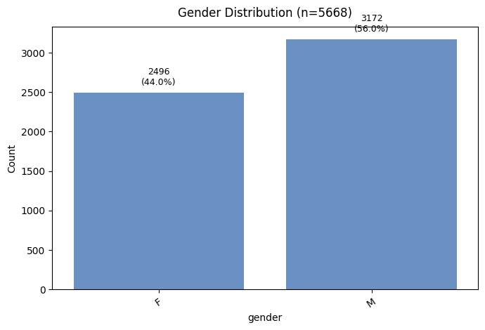

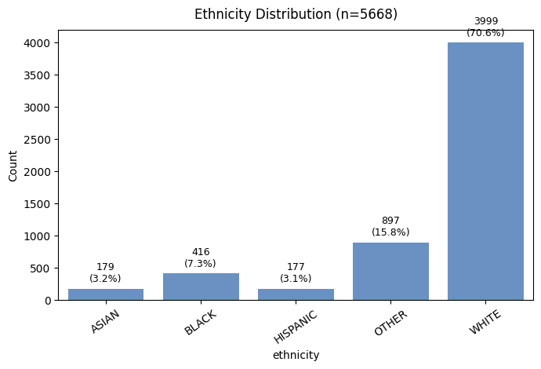

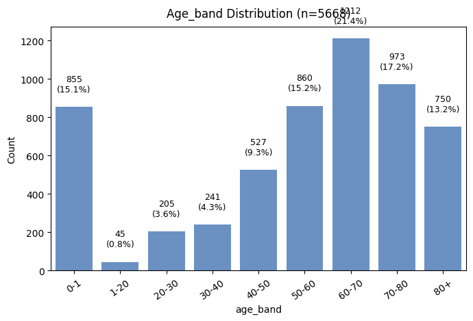

```python
# Demographic distribution diagnostics
import pandas as _pd, numpy as _np, matplotlib.pyplot as _plt, seaborn as _sns

# Reconstruct a compact group support table from metrics (already filtered to test if applicable)
# metrics: target, group_category, group_value, n, prevalence
# We'll aggregate across targets taking the max n observed per (category,value) to avoid per-target duplication.
_support = (metrics.groupby(['group_category','group_value'])
                 .agg(n=('n','max'))
                 .reset_index())
# Total subjects approximated by max group size among gender or ethnicity (safer: get unique count from any target's base subjects)
# For a robust denominator we infer by summing disjoint gender flags if present; else we use max n across categories.
_gender_rows = _support[_support.group_category=='gender']
if len(_gender_rows) and _gender_rows['n'].sum() > 0 and abs(_gender_rows['n'].sum() - _gender_rows['n'].max()) > 1:
    denom = int(_gender_rows['n'].sum())
else:
    denom = int(_support['n'].max())
_support['pct'] = (_support['n'] / denom * 100).round(2)

print('Inferred total subjects:', denom)
print('Group support (any category):')
_display_cols = _support.sort_values(['group_category','group_value'])
_display_cols

# Separate bar plots per category with larger figures and improved margins
for cat in ['gender','ethnicity','age_band']:
    sub = _support[_support.group_category==cat]
    if sub.empty:
        continue
    ordered = sub.copy()
    if cat == 'age_band':
        import re as _re
        def _age_key(v):
            s=str(v)
            if s.startswith('<'): return -0.1
            if '+' in s:
                try: return float(s.replace('+',''))
                except: return 9e9
            if '-' in s:
                try: return float(s.split('-')[0])
                except: return 9e9
            m=_re.search(r'(\d+)', s)
            return float(m.group(1)) if m else 9e9
        ordered = ordered.sort_values(by='group_value', key=lambda s: s.map(_age_key))
    else:
        ordered = ordered.sort_values('group_value')
    horiz = len(ordered) > 10
    fig_h = 4.8 if not horiz else max(4.5,0.55*len(ordered))
    fig_w = 7.0 if not horiz else 7.5
    _plt.figure(figsize=(fig_w, fig_h))
    if horiz:
        _sns.barplot(data=ordered, y='group_value', x='n', color='#5B8FD1')
        for p in _plt.gca().patches:
            val=p.get_width(); _plt.gca().text(val+ (0.008*denom), p.get_y()+p.get_height()/2, f'{val} ({val/denom*100:.1f}%)', va='center', fontsize=9)
        _plt.xlabel('Count'); _plt.ylabel(f'{cat}')
    else:
        _sns.barplot(data=ordered, x='group_value', y='n', color='#5B8FD1')
        for p in _plt.gca().patches:
            val=p.get_height(); _plt.gca().text(p.get_x()+p.get_width()/2, val + denom*0.012, f'{int(val)}\n({val/denom*100:.1f}%)', ha='center', va='bottom', fontsize=9)
        _plt.ylabel('Count'); _plt.xlabel(f'{cat}')
        _plt.xticks(rotation=35)
    _plt.title(f'{cat.capitalize()} Distribution (n={denom})', pad=10)
    _plt.tight_layout()

if set(['gender','ethnicity']).issubset(set(_support.group_category)):
    print('\n[Note] Joint gender-ethnicity distribution not available from aggregated metrics alone (requires original feature matrix).')
```

## 1. Overview

We first summarize the count of evaluated groups per target and category, and basic distribution of performance deltas (ΔAUC, ΔF1).

```python
summary = (metrics.groupby(['target','group_category'])
           .agg(groups=('group_value','nunique'),
                min_n=('n','min'), max_n=('n','max'),
                mean_delta_auc=('delta_auc','mean'),
                mean_delta_f1=('delta_f1','mean'))
           .reset_index())
summary
```

|  | target | group_category | groups | min_n | max_n | mean_delta_auc | mean_delta_f1 |
| --- | --- | --- | --- | --- | --- | --- | --- |
| 0 | mortality | age_band | 9 | 45 | 1212 | 0.005857 | -0.179736 |
| 1 | mortality | ethnicity | 5 | 177 | 3999 | 0.006745 | -0.041699 |
| 2 | mortality | gender | 2 | 2496 | 3172 | -0.001396 | 0.000158 |
| 3 | prolonged_los | age_band | 9 | 45 | 1212 | -0.009838 | -0.011464 |
| 4 | prolonged_los | ethnicity | 5 | 177 | 3999 | 0.020273 | -0.002784 |
| 5 | prolonged_los | gender | 2 | 2496 | 3172 | -0.000778 | -0.001063 |
| 6 | readmission | age_band | 9 | 45 | 1212 | -0.015059 | 0.006612 |
| 7 | readmission | ethnicity | 5 | 177 | 3999 | 0.013912 | -0.023435 |
| 8 | readmission | gender | 2 | 2496 | 3172 | 0.001781 | 0.000747 |

## 2. Disparity Threshold Flags

Flag groups whose absolute ΔAUC or ΔF1 exceed configurable thresholds (default 0.05).

```python
DELTA_THRESHOLD = 0.05
flagged = metrics[(metrics['delta_auc'].abs() > DELTA_THRESHOLD) | (metrics['delta_f1'].abs() > DELTA_THRESHOLD)]
flagged.sort_values(['target','group_category','delta_f1'], ascending=[True, True, False])
```

|  | target | prob_source | group_category | group_value | n | prevalence | auc | pr_auc | brier | threshold | f1 | precision | recall | global_auc | global_f1 | delta_auc | delta_f1 |
| --- | --- | --- | --- | --- | --- | --- | --- | --- | --- | --- | --- | --- | --- | --- | --- | --- | --- |
| 8 | mortality | base_cal | age_band | 80+ | 750 | 0.224000 | 0.766282 | 0.474950 | 0.145235 | 0.206455 | 0.516432 | 0.426357 | 0.654762 | 0.861058 | 0.449754 | -0.094776 | 0.066678 |
| 4 | mortality | base_cal | age_band | 40-50 | 527 | 0.096774 | 0.873744 | 0.384588 | 0.072188 | 0.206455 | 0.369565 | 0.414634 | 0.333333 | 0.861058 | 0.449754 | 0.012686 | -0.080189 |
| 5 | mortality | base_cal | age_band | 50-60 | 860 | 0.083721 | 0.854413 | 0.336249 | 0.064205 | 0.206455 | 0.345324 | 0.358209 | 0.333333 | 0.861058 | 0.449754 | -0.006644 | -0.104430 |
| 3 | mortality | base_cal | age_band | 30-40 | 241 | 0.053942 | 0.906883 | 0.389751 | 0.041153 | 0.206455 | 0.300000 | 0.428571 | 0.230769 | 0.861058 | 0.449754 | 0.045825 | -0.149754 |
| 0 | mortality | base_cal | age_band | 0-1 | 855 | 0.002339 | 0.866061 | 0.252347 | 0.002131 | 0.206455 | 0.000000 | 0.000000 | 0.000000 | 0.861058 | 0.449754 | 0.005003 | -0.449754 |
| 1 | mortality | base_cal | age_band | 1-20 | 45 | 0.044444 | 0.941860 | 0.366667 | 0.038582 | 0.206455 | 0.000000 | 0.000000 | 0.000000 | 0.861058 | 0.449754 | 0.080803 | -0.449754 |
| 2 | mortality | base_cal | age_band | 20-30 | 205 | 0.014634 | 0.963696 | 0.260684 | 0.012695 | 0.206455 | 0.000000 | 0.000000 | 0.000000 | 0.861058 | 0.449754 | 0.102639 | -0.449754 |
| 12 | mortality | base_cal | ethnicity | OTHER | 897 | 0.146042 | 0.894221 | 0.548125 | 0.087726 | 0.206455 | 0.573290 | 0.500000 | 0.671756 | 0.861058 | 0.449754 | 0.033163 | 0.123536 |
| 9 | mortality | base_cal | ethnicity | ASIAN | 179 | 0.055866 | 0.915385 | 0.533355 | 0.039548 | 0.206455 | 0.480000 | 0.400000 | 0.600000 | 0.861058 | 0.449754 | 0.054327 | 0.030246 |
| 11 | mortality | base_cal | ethnicity | HISPANIC | 177 | 0.039548 | 0.778151 | 0.093026 | 0.044881 | 0.206455 | 0.111111 | 0.090909 | 0.142857 | 0.861058 | 0.449754 | -0.082907 | -0.338643 |
| 16 | prolonged_los | base_cal | age_band | 0-1 | 855 | 0.403509 | 0.930014 | 0.865338 | 0.099950 | 0.385050 | 0.842105 | 0.806366 | 0.881159 | 0.822002 | 0.769160 | 0.108013 | 0.072946 |
| 18 | prolonged_los | base_cal | age_band | 20-30 | 205 | 0.473171 | 0.882732 | 0.863564 | 0.143026 | 0.385050 | 0.794258 | 0.741071 | 0.855670 | 0.822002 | 0.769160 | 0.060730 | 0.025099 |
| 24 | prolonged_los | base_cal | age_band | 80+ | 750 | 0.562667 | 0.770063 | 0.782730 | 0.193609 | 0.385050 | 0.767635 | 0.682657 | 0.876777 | 0.822002 | 0.769160 | -0.051939 | -0.001525 |
| 19 | prolonged_los | base_cal | age_band | 30-40 | 241 | 0.497925 | 0.757197 | 0.718819 | 0.200732 | 0.385050 | 0.706827 | 0.682171 | 0.733333 | 0.822002 | 0.769160 | -0.064805 | -0.062332 |
| 17 | prolonged_los | base_cal | age_band | 1-20 | 45 | 0.400000 | 0.790123 | 0.773282 | 0.177038 | 0.385050 | 0.666667 | 0.619048 | 0.722222 | 0.822002 | 0.769160 | -0.031878 | -0.102493 |
| 27 | prolonged_los | base_cal | ethnicity | HISPANIC | 177 | 0.508475 | 0.877395 | 0.879262 | 0.143714 | 0.385050 | 0.789744 | 0.733333 | 0.855556 | 0.822002 | 0.769160 | 0.055393 | 0.020584 |
| 25 | prolonged_los | base_cal | ethnicity | ASIAN | 179 | 0.413408 | 0.873295 | 0.804964 | 0.145664 | 0.385050 | 0.736842 | 0.649485 | 0.851351 | 0.822002 | 0.769160 | 0.051293 | -0.032317 |
| 34 | readmission | base_cal | age_band | 20-30 | 205 | 0.043902 | 0.669218 | 0.147887 | 0.041147 | 0.057625 | 0.333333 | 0.266667 | 0.444444 | 0.638268 | 0.129290 | 0.030950 | 0.204044 |
| 37 | readmission | base_cal | age_band | 50-60 | 860 | 0.053488 | 0.573697 | 0.077679 | 0.050381 | 0.057625 | 0.133333 | 0.089552 | 0.260870 | 0.638268 | 0.129290 | -0.064571 | 0.004044 |
| 36 | readmission | base_cal | age_band | 40-50 | 527 | 0.037951 | 0.569428 | 0.056999 | 0.036383 | 0.057625 | 0.100000 | 0.062500 | 0.250000 | 0.638268 | 0.129290 | -0.068840 | -0.029290 |
| 32 | readmission | base_cal | age_band | 0-1 | 855 | 0.017544 | 0.691429 | 0.048140 | 0.017040 | 0.057625 | 0.066667 | 0.066667 | 0.066667 | 0.638268 | 0.129290 | 0.053161 | -0.062623 |
| 35 | readmission | base_cal | age_band | 30-40 | 241 | 0.037344 | 0.664990 | 0.175987 | 0.035258 | 0.057625 | 0.055556 | 0.037037 | 0.111111 | 0.638268 | 0.129290 | 0.026722 | -0.073734 |
| 43 | readmission | base_cal | ethnicity | HISPANIC | 177 | 0.033898 | 0.763158 | 0.206833 | 0.031142 | 0.057625 | 0.275862 | 0.173913 | 0.666667 | 0.638268 | 0.129290 | 0.124890 | 0.146572 |
| 42 | readmission | base_cal | ethnicity | BLACK | 416 | 0.033654 | 0.586976 | 0.052189 | 0.032727 | 0.057625 | 0.118812 | 0.068966 | 0.428571 | 0.638268 | 0.129290 | -0.051292 | -0.010478 |
| 41 | readmission | base_cal | ethnicity | ASIAN | 179 | 0.027933 | 0.604598 | 0.042500 | 0.027475 | 0.057625 | 0.000000 | 0.000000 | 0.000000 | 0.638268 | 0.129290 | -0.033670 | -0.129290 |
| 44 | readmission | base_cal | ethnicity | OTHER | 897 | 0.032330 | 0.675453 | 0.052885 | 0.031055 | 0.057625 | 0.000000 | 0.000000 | 0.000000 | 0.638268 | 0.129290 | 0.037185 | -0.129290 |

## 3. Bar Charts: ΔAUC & ΔF1 by Group

For each target and group category, plot the deviation from global performance. Positive values indicate better performance than the overall cohort; negative values indicate worse.

```
Generated 18 disparity panels (delta_auc + delta_f1).
```

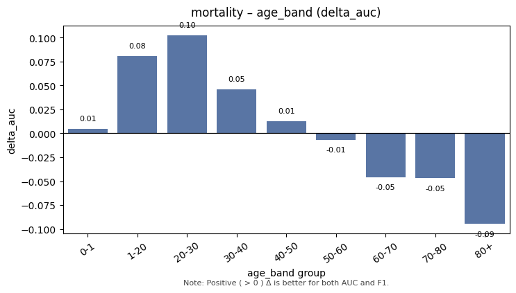

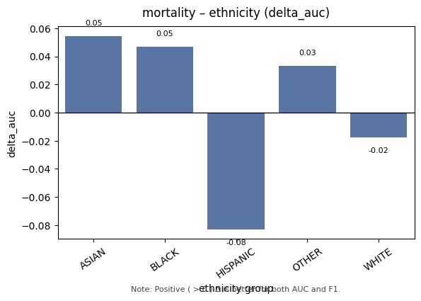

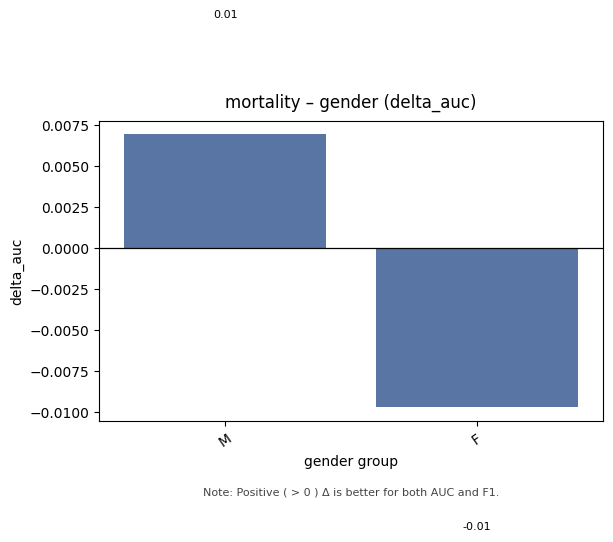

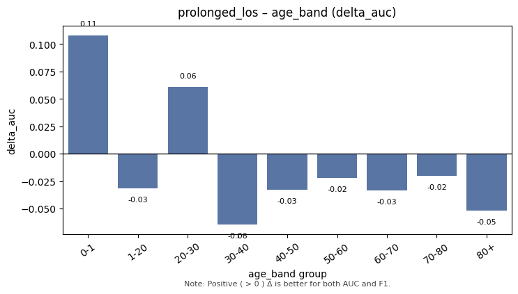

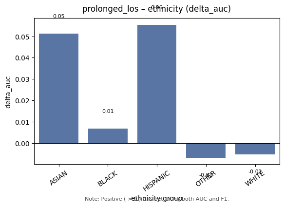

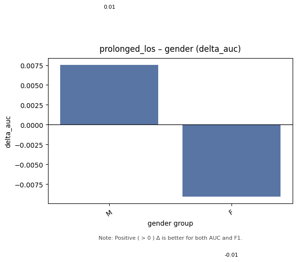

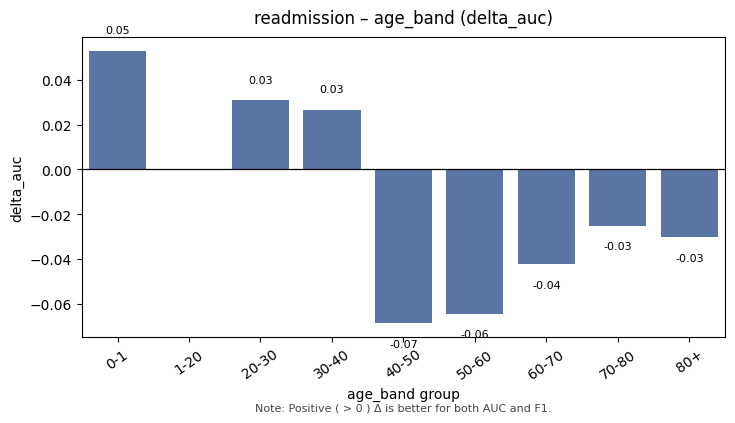

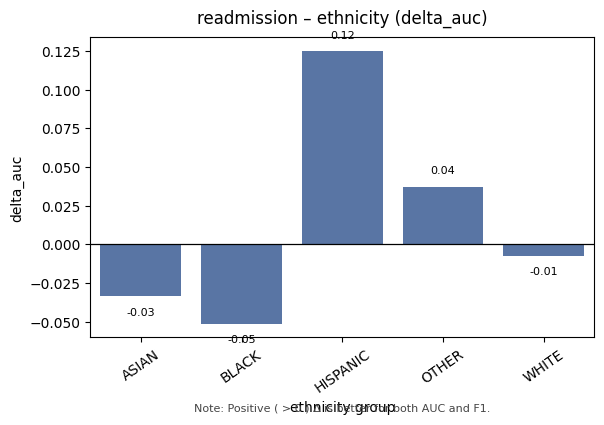

[figure not shown]

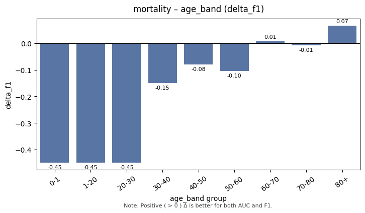

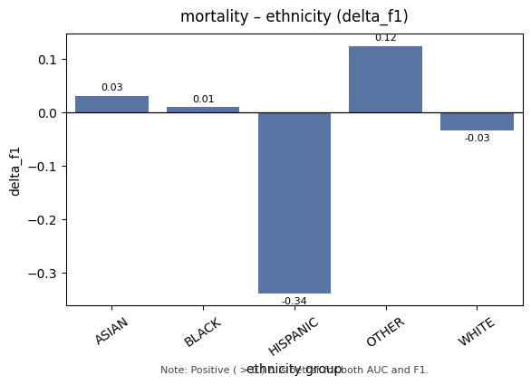

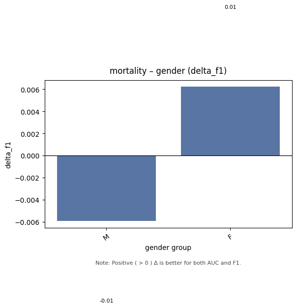

[6 more figures not shown]

```python
# Adaptive disparity bar charts (handles many age groups gracefully)
import re, math
import seaborn as sns, matplotlib.pyplot as plt

AGE_RE = re.compile(r"(\d+)")

ANNOTATION_TEXT = "Note: Positive ( > 0 ) Δ is better for both AUC and F1."

# Tunable sizing constants
BASE_HEIGHT = 5.0  # was 4.6
BASE_WIDTH_PER_BAR = 0.7  # was 0.6
HORIZONTAL_ROW_HEIGHT = 0.50  # was 0.45
EXTRA_RIGHT_MARGIN = 0.15  # space for annotation (fraction of figure width)
BOTTOM_ANNOTATION_PAD = 0.22  # space below for annotation on vertical layout

def _age_sort_key(label: str):
    s = str(label)
    if s.startswith('<'):
        try: return float(s[1:]) - 0.1
        except: return -0.1
    if '+' in s:
        try: return float(s.replace('+',''))
        except: return 9e9
    if '-' in s:
        try: return float(s.split('-')[0])
        except: return 9e9
    m = AGE_RE.search(s)
    return float(m.group(1)) if m else 9e9

def _ordered_values(sub):
    cat = sub['group_category'].iloc[0]
    vals = sub['group_value'].astype(str).unique().tolist()
    if cat == 'age_band':
        vals = sorted(vals, key=_age_sort_key)
    elif cat == 'gender':
        ordering = {'M': 0, 'F': 1}
        vals = sorted(vals, key=lambda v: ordering.get(v.upper(), 99))
    else:
        vals = sorted(vals)
    return vals

def plot_disparity_panels(metrics, metric_col: str):
    figs = []
    for (tgt, cat), sub in metrics.groupby(['target','group_category']):
        sub = sub.copy()
        order = _ordered_values(sub)
        sub['group_value'] = sub['group_value'].astype(str)
        sub = sub.set_index('group_value').loc[order].reset_index()
        n = len(order)
        horizontal = n > 10
        if horizontal:
            height = max(4.2, HORIZONTAL_ROW_HEIGHT * n)
            width = 7.0
            fig, ax = plt.subplots(figsize=(width, height))
            sns.barplot(data=sub, y='group_value', x=metric_col, ax=ax, color='#4C72B0')
            ax.axvline(0, color='black', linewidth=0.9)
            ax.set_ylabel(f'{cat} group')
            ax.set_xlabel(metric_col)
        else:
            width = max(6.5, BASE_WIDTH_PER_BAR * n + 2.0)
            fig, ax = plt.subplots(figsize=(width, BASE_HEIGHT))
            sns.barplot(data=sub, x='group_value', y=metric_col, ax=ax, color='#4C72B0')
            ax.axhline(0, color='black', linewidth=0.9)
            ax.set_xlabel(f'{cat} group')
            ax.set_ylabel(metric_col)
            ax.tick_params(axis='x', rotation=35)
        for patch in ax.patches:
            val = patch.get_width() if horizontal else patch.get_height()
            if not math.isnan(val):
                if horizontal:
                    ax.text(val + (0.006 if val>=0 else -0.006), patch.get_y() + patch.get_height()/2,
                            f'{val:.2f}', va='center', ha='left' if val>=0 else 'right', fontsize=8)
                else:
                    ax.text(patch.get_x() + patch.get_width()/2, val + (0.007 if val>=0 else -0.007),
                            f'{val:.2f}', ha='center', va='bottom' if val>=0 else 'top', fontsize=8)
        ax.set_title(f'{tgt} – {cat} ({metric_col})', pad=10)
        if horizontal:
            ax.text(1.02, 1.02, ANNOTATION_TEXT, ha='left', va='bottom', transform=ax.transAxes, fontsize=8, color='#444', wrap=True)
            fig.subplots_adjust(right=1-EXTRA_RIGHT_MARGIN/2)
        else:
            ax.text(0.5, -BOTTOM_ANNOTATION_PAD, ANNOTATION_TEXT, ha='center', va='top', transform=ax.transAxes, fontsize=8, color='#444', wrap=True)
            fig.subplots_adjust(bottom=0.28)
        figs.append(fig)
    return figs

figs_auc = plot_disparity_panels(metrics, 'delta_auc')
figs_f1 = plot_disparity_panels(metrics, 'delta_f1')
print(f'Generated {len(figs_auc) + len(figs_f1)} disparity panels (delta_auc + delta_f1).')
```

## 4. Heatmaps: AUC per Group

Pivot AUC values to visualize performance consistency across demographic groups.

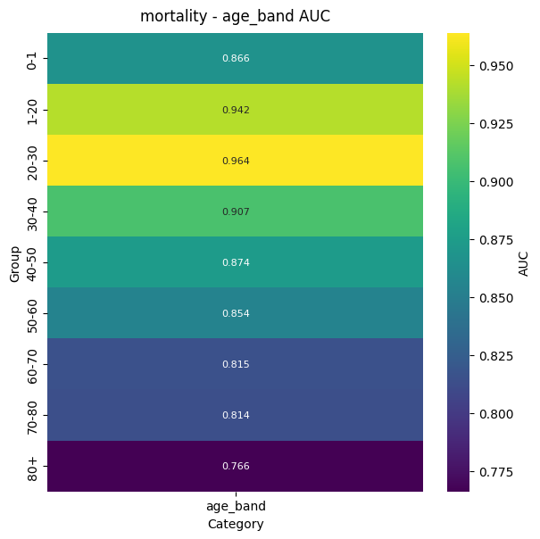

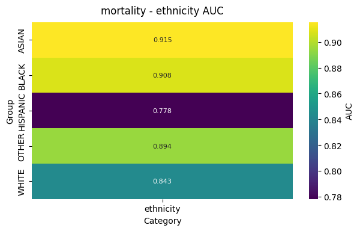

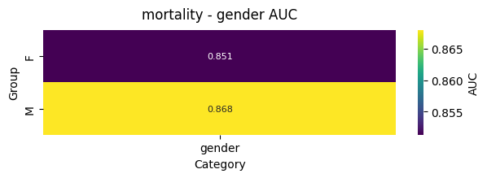

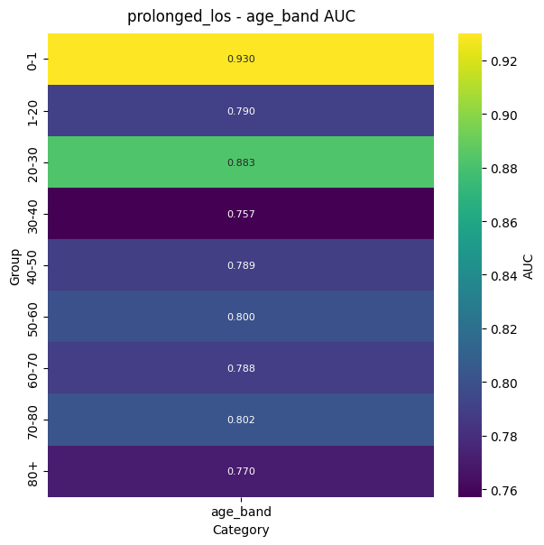

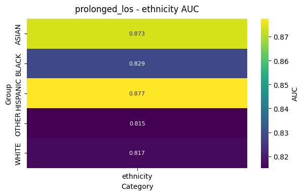

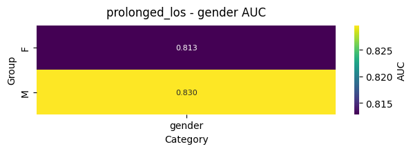

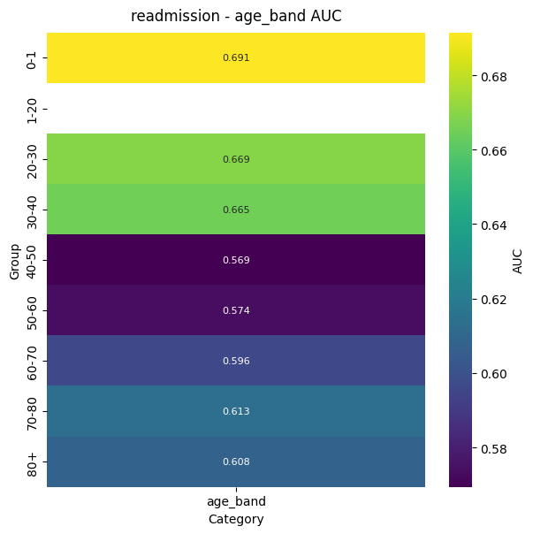

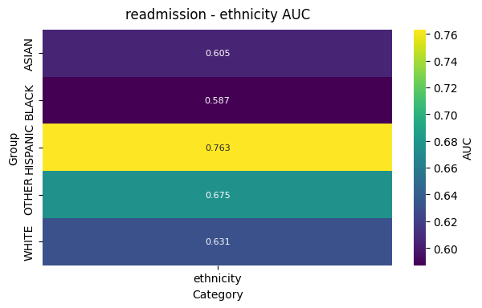

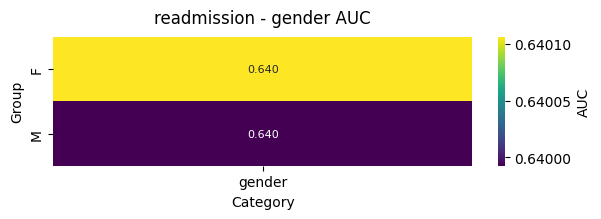

```python
def make_heatmap(df, target, category, value_col='auc'):
    sub = df[(df['target']==target) & (df['group_category']==category)]
    if sub.empty: return None
    pivot = sub.pivot(index='group_value', columns='group_category', values=value_col)
    if pivot.shape[1] == 1:
        pivot = sub.set_index('group_value')[value_col].to_frame(name=category)
    fig_h = 0.55 * len(pivot) + 1.2
    fig_w = 6.2
    plt.figure(figsize=(fig_w, fig_h))
    sns.heatmap(pivot, annot=True, fmt='.3f', cmap='viridis', cbar_kws={'label': value_col.upper()}, annot_kws={'fontsize':8})
    plt.title(f'{target} - {category} {value_col.upper()}', pad=10)
    plt.ylabel('Group')
    plt.xlabel('Category')
    plt.tight_layout()
for tgt in metrics['target'].unique():
    for cat in metrics['group_category'].unique():
        make_heatmap(metrics, tgt, cat, 'auc')
```

## 5. Scatter: Prevalence vs. AUC

Examine relationship between outcome prevalence and AUC per group value (color-coded by category).

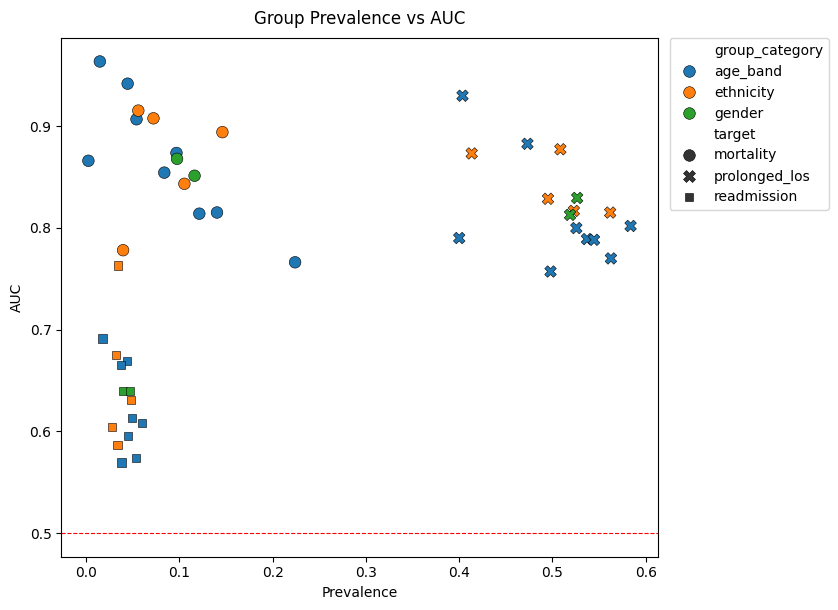

```python
plt.figure(figsize=(8.5,6.2))
sns.scatterplot(data=metrics, x='prevalence', y='auc', hue='group_category', style='target', s=70, edgecolor='black', linewidth=0.4)
plt.axhline(0.5, color='red', linestyle='--', linewidth=0.8)
plt.title('Group Prevalence vs AUC', pad=10)
plt.xlabel('Prevalence')
plt.ylabel('AUC')
plt.legend(bbox_to_anchor=(1.02,1), loc='upper left', borderaxespad=0.)
plt.tight_layout()
```

## 6. Save Figures (Optional)

Run this cell to save the last generated figures to the artifacts directory.

```python
SAVE_PLOTS = True
if SAVE_PLOTS:
    from pathlib import Path
    candidate_dirs = [ARTIFACT_DIR, Path('artifacts')]
    use_dir = None
    for d in candidate_dirs:
        if (d / 'fairness_group_metrics.csv').exists() or (d / 'fairness_group_metrics_test.csv').exists():
            use_dir = d
            break
    if use_dir is None:
        raise FileNotFoundError('Could not locate artifacts directory with fairness metrics CSV')
    out_dir = use_dir / 'fairness_plots'
    out_dir.mkdir(parents=True, exist_ok=True)
    import seaborn as sns, matplotlib.pyplot as plt, re as _re
    from math import isnan
    def _age_key(v):
        s=str(v)
        if s.startswith('<'): return -0.1
        if '+' in s:
            try: return float(s.replace('+',''))
            except: return 9e9
        if '-' in s:
            try: return float(s.split('-')[0])
            except: return 9e9
        m=_re.search(r'(\d+)', s)
        return float(m.group(1)) if m else 9e9
    _support = (metrics.groupby(['group_category','group_value']).agg(n=('n','max')).reset_index())
    gender_rows = _support[_support.group_category=='gender']
    if len(gender_rows) and gender_rows['n'].sum() > 0 and abs(gender_rows['n'].sum() - gender_rows['n'].max()) > 1:
        denom = int(gender_rows['n'].sum())
    else:
        denom = int(_support['n'].max())
    for cat in ['gender','ethnicity','age_band']:
        sub = _support[_support.group_category==cat]
        if sub.empty: continue
        if cat == 'age_band':
            sub = sub.sort_values(by='group_value', key=lambda s: s.map(_age_key))
        else:
            sub = sub.sort_values('group_value')
        horiz = len(sub) > 10
        fig_h = 4.8 if not horiz else max(4.5,0.55*len(sub))
        fig_w = 7.0 if not horiz else 7.5
        plt.figure(figsize=(fig_w, fig_h))
        if horiz:
            sns.barplot(data=sub, y='group_value', x='n', color='#5B8FD1')
            for p in plt.gca().patches:
                val=p.get_width(); plt.gca().text(val + (0.008*denom), p.get_y()+p.get_height()/2, f'{int(val)} ({val/denom*100:.1f}%)', va='center', fontsize=9)
            plt.xlabel('Count'); plt.ylabel(f'{cat}')
        else:
            sns.barplot(data=sub, x='group_value', y='n', color='#5B8FD1')
            for p in plt.gca().patches:
                val=p.get_height(); plt.gca().text(p.get_x()+p.get_width()/2, val + denom*0.012, f'{int(val)}\n({val/denom*100:.1f}%)', ha='center', va='bottom', fontsize=9)
            plt.ylabel('Count'); plt.xlabel(f'{cat}'); plt.xticks(rotation=35)
        plt.title(f'{cat.capitalize()} Distribution (n={denom})', pad=10)
        plt.tight_layout()
        plt.savefig(out_dir / f'distribution_{cat}.png', dpi=170)
        plt.close()
    for i, fig in enumerate(figs_auc):
        fig.savefig(out_dir / f'delta_auc_panel_{i+1}.png', dpi=170, bbox_inches='tight')
        plt.close(fig)
    for i, fig in enumerate(figs_f1):
        fig.savefig(out_dir / f'delta_f1_panel_{i+1}.png', dpi=170, bbox_inches='tight')
        plt.close(fig)
    plt.figure(figsize=(8,6))
    sns.scatterplot(data=metrics, x='prevalence', y='auc', hue='group_category', style='target', s=70)
    plt.axhline(0.5, color='red', linestyle='--', linewidth=0.8)
    plt.title('Group Prevalence vs AUC')
    plt.tight_layout()
    plt.savefig(out_dir / 'prevalence_vs_auc.png', dpi=170)
    plt.close()
    note_path = out_dir / 'README.txt'
    note_path.write_text(
        'Disparity Panel Interpretation\n'\
        '------------------------------\n'\
        'Figures delta_*_panel_*.png plot ΔAUC or ΔF1 relative to the global (overall cohort) value.\n'\
        'Positive ( > 0 ) delta means the group performs better than overall; negative ( < 0 ) delta means worse.\n'\
        'Higher is better for both AUC and F1. Bars are oriented horizontally when there are many groups.\n')
    print(f'Saved demographic distributions, disparity panels (with interpretation), scatter, and README to {out_dir.resolve()}')
```

[output not shown]

## 7. Next Steps

- Adjust `DELTA_THRESHOLD` if policy uses different disparity criteria.
- Incorporate confidence intervals or permutation tests for statistical significance.
- Extend audit to calibration (e.g., reliability curves) per group.